Kentaro Asaba's personal homepage

# Recent Posts

# Links

## Problems of Linear Regression

March-14-2020

- Omitted Variables Bias
- Bad Control
- Attenuation Bias

# Objective

- To show and visualize the problems of linear regression with simulations.

```python
import numpy as np
import matplotlib.pyplot as plt
import statsmodels.api as sm
from mpl_toolkits.mplot3d import Axes3D
import plotly.graph_objects as go
```

# Very simple linear regression

#### Underlying Model A

$$y = 100 + 2x_1 + \varepsilon,$$$$\varepsilon \sim \mathcal{N}(0, 10)$$

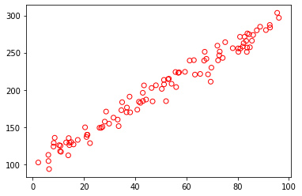

```python
n = 100

x1 = 100*np.random.rand(n)
y = 100 + x1*2 + np.random.normal(0, 10, size=n)

plt.scatter(x1, y, marker='o', facecolors='none', edgecolors='red')
plt.show()
```

```python
# Add the bias term
X_modelA = np.column_stack((np.repeat(1, n), x1))

ols = sm.OLS(y, X_modelA)
ols_result = ols.fit()
# Now you have at your disposition several error estimates, e.g.
ols_result.HC0_se
```

```
array([1.77369587, 0.03137929])
```

```python
print(ols_result.summary())
```

```
                            OLS Regression Results
==============================================================================
Dep. Variable:                      y   R-squared:                       0.973
Model:                            OLS   Adj. R-squared:                  0.972
Method:                 Least Squares   F-statistic:                     3469.
Date:                Sat, 21 Mar 2020   Prob (F-statistic):           2.63e-78
Time:                        16:41:05   Log-Likelihood:                -364.46
No. Observations:                 100   AIC:                             732.9
Df Residuals:                      98   BIC:                             738.1
Df Model:                           1
Covariance Type:            nonrobust
==============================================================================
                 coef    std err          t      P>|t|      [0.025      0.975]
------------------------------------------------------------------------------
const         99.7504      1.936     51.534      0.000      95.909     103.592
x1             2.0151      0.034     58.895      0.000       1.947       2.083
==============================================================================
Omnibus:                        1.449   Durbin-Watson:                   1.905
Prob(Omnibus):                  0.485   Jarque-Bera (JB):                1.223
Skew:                          -0.271   Prob(JB):                        0.543
Kurtosis:                       3.000   Cond. No.                         117.
==============================================================================

Warnings:
[1] Standard Errors assume that the covariance matrix of the errors is correctly specified.
```

We are able to correctly reproduce the coeffient.

[figure not shown]

# Regression with two correlated independent variables

#### Underlying Model 2

$$y = 100 + 2x_1 + 3x_2 + \varepsilon,$$$$\varepsilon \sim \mathcal{N}(0, 10)$$

```python
n = 200

X_modelB = np.random.multivariate_normal(mean=[100,50], cov=[[50,25], [25, 20]], size=n)
x1 = np.array([x[0] for x in X_modelB])
x2 = np.array([x[1] for x in X_modelB])
y = 100 + x1*2 + x2*3 + np.random.normal(0, 10, size=n)
```

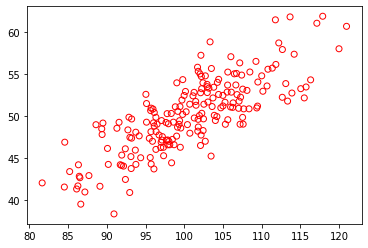

```python
plt.scatter(x1, x2, facecolors='none', edgecolors='red')
plt.show()
```

```python
fig = go.Figure(data=[go.Scatter3d(x=x1, y=x2, z=y,
                                   mode='markers')])


# fig.update_layout(scene = dict(
#                     xaxis_title=r'x1',
#                     yaxis_title=r'x2',
#                     zaxis_title=r'y'),
#                     width=700,
#                     margin=dict(r=20, b=10, l=10, t=10))

fig.show()
```

[interactive chart not shown]

```python
X_modelB_sm = np.column_stack((np.repeat(1, n), X_modelB))
```

```python
ols = sm.OLS(y, X_modelB_sm)
ols_result = ols.fit()
```

```python
print(ols_result.summary())
```

```
                            OLS Regression Results
==============================================================================
Dep. Variable:                      y   R-squared:                       0.897
Model:                            OLS   Adj. R-squared:                  0.896
Method:                 Least Squares   F-statistic:                     855.1
Date:                Sat, 21 Mar 2020   Prob (F-statistic):           7.69e-98
Time:                        16:41:06   Log-Likelihood:                -733.59
No. Observations:                 200   AIC:                             1473.
Df Residuals:                     197   BIC:                             1483.
Df Model:                           2
Covariance Type:            nonrobust
==============================================================================
                 coef    std err          t      P>|t|      [0.025      0.975]
------------------------------------------------------------------------------
const         85.5788      9.033      9.474      0.000      67.766     103.392
x1             2.1733      0.148     14.729      0.000       1.882       2.464
x2             2.9482      0.255     11.546      0.000       2.445       3.452
==============================================================================
Omnibus:                        6.748   Durbin-Watson:                   2.123
Prob(Omnibus):                  0.034   Jarque-Bera (JB):                9.811
Skew:                          -0.162   Prob(JB):                      0.00740
Kurtosis:                       4.036   Cond. No.                     1.51e+03
==============================================================================

Warnings:
[1] Standard Errors assume that the covariance matrix of the errors is correctly specified.
[2] The condition number is large, 1.51e+03. This might indicate that there are
strong multicollinearity or other numerical problems.
```

↑With knowledge about $x_1 \text{and } x_2$, we can properly estimate the parameters (CIA)

[figure not shown]

# 3.2.2 Omitted Variables Bias Formula

Then assume that we don't know about $x_2$ when running regression.

```python
X_modelB_OV = np.column_stack((np.repeat(1, n), x1))
```

```python
ols = sm.OLS(y, X_modelB_OV)
ols_result = ols.fit()
print(ols_result.summary())
```

```
                            OLS Regression Results
==============================================================================
Dep. Variable:                      y   R-squared:                       0.827
Model:                            OLS   Adj. R-squared:                  0.826
Method:                 Least Squares   F-statistic:                     945.3
Date:                Sat, 21 Mar 2020   Prob (F-statistic):           2.56e-77
Time:                        16:41:06   Log-Likelihood:                -785.27
No. Observations:                 200   AIC:                             1575.
Df Residuals:                     198   BIC:                             1581.
Df Model:                           1
Covariance Type:            nonrobust
==============================================================================
                 coef    std err          t      P>|t|      [0.025      0.975]
------------------------------------------------------------------------------
const         96.6031     11.601      8.327      0.000      73.725     119.481
x1             3.5324      0.115     30.745      0.000       3.306       3.759
==============================================================================
Omnibus:                        5.693   Durbin-Watson:                   2.121
Prob(Omnibus):                  0.058   Jarque-Bera (JB):                7.511
Skew:                          -0.156   Prob(JB):                       0.0234
Kurtosis:                       3.897   Cond. No.                     1.34e+03
==============================================================================

Warnings:
[1] Standard Errors assume that the covariance matrix of the errors is correctly specified.
[2] The condition number is large, 1.34e+03. This might indicate that there are
strong multicollinearity or other numerical problems.
```

[figure not shown]

The coefficient of $x_1$ is too large because we did not have $x_2$, which is very important

# 3.2.3 Bad Control

Including bad variables may couse problems

Example:

## Underlying Model C

① What if we regress $y$ on $x_1$ AND $x_2$??

```python
n = 200

x1 = 100*np.random.rand(n)
x2 = 500 + x1*5 + np.random.normal(0, 1.5, size=n)
y = 100 + x1*2 + np.random.normal(0, 10, size=n)
```

```python
fig = go.Figure(data=[go.Scatter3d(x=x1, y=x2, z=y,
                                   mode='markers')])

# fig.update_layout(scene = dict(
#                     xaxis_title='x1',
#                     yaxis_title='x2',
#                     zaxis_title='y'),
#                     width=700,
#                     margin=dict(r=20, b=10, l=10, t=10))


fig.show()
```

[interactive chart not shown]

```python
X_modelC_BV = np.concatenate([x1.reshape(n, 1), x2.reshape(n, 1)], 1)
X_modelC_BV = np.column_stack((np.repeat(1, n), X_modelC_BV))
```

```python
ols = sm.OLS(y, X_modelC_BV)
ols_result = ols.fit()
print(ols_result.summary())
```

```
                            OLS Regression Results
==============================================================================
Dep. Variable:                      y   R-squared:                       0.968
Model:                            OLS   Adj. R-squared:                  0.968
Method:                 Least Squares   F-statistic:                     2996.
Date:                Sat, 21 Mar 2020   Prob (F-statistic):          3.41e-148
Time:                        16:41:07   Log-Likelihood:                -761.29
No. Observations:                 200   AIC:                             1529.
Df Residuals:                     197   BIC:                             1538.
Df Model:                           2
Covariance Type:            nonrobust
==============================================================================
                 coef    std err          t      P>|t|      [0.025      0.975]
------------------------------------------------------------------------------
const       -129.9196    267.074     -0.486      0.627    -656.610     396.771
x1            -0.3080      2.672     -0.115      0.908      -5.578       4.962
x2             0.4606      0.534      0.862      0.390      -0.593       1.515
==============================================================================
Omnibus:                        0.947   Durbin-Watson:                   1.958
Prob(Omnibus):                  0.623   Jarque-Bera (JB):                1.061
Skew:                           0.129   Prob(JB):                        0.588
Kurtosis:                       2.753   Cond. No.                     2.64e+05
==============================================================================

Warnings:
[1] Standard Errors assume that the covariance matrix of the errors is correctly specified.
[2] The condition number is large, 2.64e+05. This might indicate that there are
strong multicollinearity or other numerical problems.
```

[figure not shown]

With unnecessary variable $x_2$, the estimated coefficient of $x_1$ is not precise

② Regress $y$ only on $x_1$

```python
X_modelC_OBV = np.column_stack((np.repeat(1, n), x1))
ols = sm.OLS(y, X_modelC_OBV)
ols_result = ols.fit()
print(ols_result.summary())
```

```
                            OLS Regression Results
==============================================================================
Dep. Variable:                      y   R-squared:                       0.968
Model:                            OLS   Adj. R-squared:                  0.968
Method:                 Least Squares   F-statistic:                     5999.
Date:                Sat, 21 Mar 2020   Prob (F-statistic):          5.08e-150
Time:                        16:41:07   Log-Likelihood:                -761.67
No. Observations:                 200   AIC:                             1527.
Df Residuals:                     198   BIC:                             1534.
Df Model:                           1
Covariance Type:            nonrobust
==============================================================================
                 coef    std err          t      P>|t|      [0.025      0.975]
------------------------------------------------------------------------------
const        100.2674      1.506     66.566      0.000      97.297     103.238
x1             1.9953      0.026     77.452      0.000       1.944       2.046
==============================================================================
Omnibus:                        1.076   Durbin-Watson:                   1.979
Prob(Omnibus):                  0.584   Jarque-Bera (JB):                1.167
Skew:                           0.125   Prob(JB):                        0.558
Kurtosis:                       2.722   Cond. No.                         114.
==============================================================================

Warnings:
[1] Standard Errors assume that the covariance matrix of the errors is correctly specified.
```

[figure not shown]

Removing the unnecessary variable brings us the right result.

# Attenuation Bias

$$y_i = 100 + 2x_{i} + \varepsilon,$$$$\varepsilon \sim \mathcal{N}(0, 10)$$

What happens to the coefficients if observed x has error, namely $$\tilde{x_{i}} = x_i + \nu,$$ $$\nu \sim \mathcal{N}(0, 20)$$

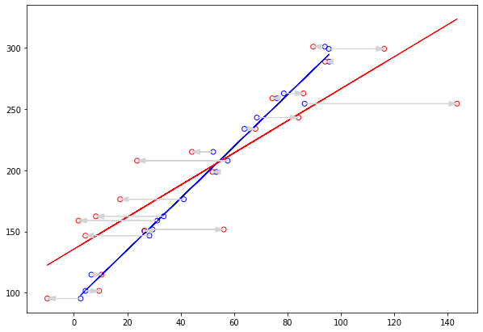

```python
n = 20

x1 = 100*np.random.rand(n)
y = 100 + x1*2 + np.random.normal(0, 10, size=n)

plt.figure(figsize=(10, 7))

plt.scatter(x1, y, marker='o', facecolors='none', edgecolors='blue')

# Add the bias term
X_modelA = np.column_stack((np.repeat(1, n), x1))

ols = sm.OLS(y, X_modelA)
ols_result = ols.fit()

plt.plot(x1, ols_result.predict(X_modelA), lw=1, color='blue')


###############################
nu = np.random.normal(0, 20, size=n)
x1_tilda = x1 + nu


plt.scatter(x1_tilda, y, marker='o', facecolors='none', edgecolors='red')

# Add the bias term
X_modelA = np.column_stack((np.repeat(1, n), x1_tilda))

ols = sm.OLS(y, X_modelA)
ols_result = ols.fit()

plt.plot(x1_tilda, ols_result.predict(X_modelA), lw=1, color='red')

arr = dict(shrink=0, width=0.1, headwidth=6,
                                headlength=10, connectionstyle='arc3',
                                facecolor='lightgray', edgecolor='lightgray')
for moto, ato, yy in zip(x1_tilda, x1, y):
    plt.annotate('', xy = (moto, yy), xytext = (ato, yy), color = "black", arrowprops = arr)

plt.show()
```

The slope of the blue line is the true coefficient.

However, the observation error in $x$ moves each blue point to the red point.

This leads to less steeper slope in red line

Newer Post Older Post

©2020 K.Asaba